# Pakiet lavaan

18 listopada 2019

## Analiza Czynnikowa

## Wprowadzenie

Własności świata szczególnie interesujące dla badaczy nie zawsze są możliwe do zmierzenia. Nazywa się je **zmiennymi latentnymi/ukrytymi** Problem ten dotyczy szczególnie nauk społecznych, jak socjologia czy psychologia.

Zwykle naukowcy starają się znaleźć jakąś **mierzalną cechę** (lub kombinację takich cech), która będzie dobrze oddawać faktyczną własność. Problem w tym, że można znaleźć bardzo dużo różnych takich cech.

\[\ x_{1} = lambda_{11}f_{1} + lambda_{12}f_{2} + ... + lambda_{1k}f_{k} + u_{1}\] \[\ x_{2} = lambda_{21}f_{1} + lambda_{22}f_{2} + ... + lambda_{2k}f_{k} + u_{2}\] \[\ ...\] \[\ x_{n} = lambda_{n1}f_{1} + lambda_{n2}f_{2} + ... + lambda_{nk}f_{k} + u_{n}\]

## Przykład

*Nie da się zmierzyć poziomu zakochania pary ludzi. Ale można:*

- *zadać im o to pytania w ankiecie,*
- *badać poziomy niektórych hormonów,*
- *przeprowadzić analizę sentymentalną wiadomości, które do siebie piszą,*
- *…*

## Exploratory Factor Analysis

**Eksploracyjna Analiza Czynnikowa** jest badaniem, w którym próbuje się odkryć zależności między grupami zmiennych mierzalnych, które wskazują na istnienie wpływających na nie zmiennych ukrytych.

W tym celu stosuje się zwykle **analizę korelacji**.

## Przykład (demokracja)

## Zmienne [1]

Mam wyniki kilku pytań ankietowych dotyczących poglądów na demokrację. Ankieta została przeprowadzona w paru krajach europejskich.

**Skala: 1 - Nie jest istotną cechą demokracji, 10 - jest istotną cechą demokracji**

- *taxRich* - Rząd opodatkowuje bogatych i oddaje ubogim
- *religiousLaw* - Autorytety religijne interpretują prawo
- *freeElection* - Liderzy są wybierani w wolnych wyborach
- *helpUnemp* - Bezrobotni otrzymują pomoc od państwa

## Zmienne [2]

- *armyTakesOver* - Armia przejmuje władzę jeśli rząd jest niekompetentny
- *civilRights* - Prawa obywatelskie chronią człowieka przed opresją państwa
- *equalIncome* - Państwo dba o równość dochodów
- *obeyRulers* - Ludzie są posłuszni rządzącym
- *genderEquality* - Kobiety mają takie same prawa jak mężczyźni
- *importance*: 1 - Demokracja nie jest istotna, 10 - Demokracja jest absolutnie istotna

## Przegląd danych [1]

Na potrzeby prezentacji dane są już po selekcji, filtrowaniu, usuwaniu braków itd.

| country | taxRich | religiousLaw | freeElection | helpUnemp | armyTakesOver | civilRights | equalIncome | obeyRulers | genderEquality | importance |
| --- | --- | --- | --- | --- | --- | --- | --- | --- | --- | --- |
| Estonia | 8 | 4 | 10 | 10 | 1 | 10 | 8 | 2 | 10 | 10 |
| Estonia | 6 | 1 | 10 | 9 | 1 | 10 | 5 | 1 | 10 | 10 |
| Estonia | 6 | 2 | 10 | 7 | 1 | 9 | 7 | 8 | 10 | 10 |
| Estonia | 10 | 6 | 10 | 10 | 7 | 10 | 8 | 8 | 8 | 10 |
| Estonia | 7 | 3 | 10 | 10 | 8 | 10 | 8 | 5 | 10 | 10 |
| Estonia | 6 | 4 | 9 | 7 | 2 | 7 | 6 | 6 | 8 | 10 |

## Przegląd danych [2] - różnice międzykrajowe

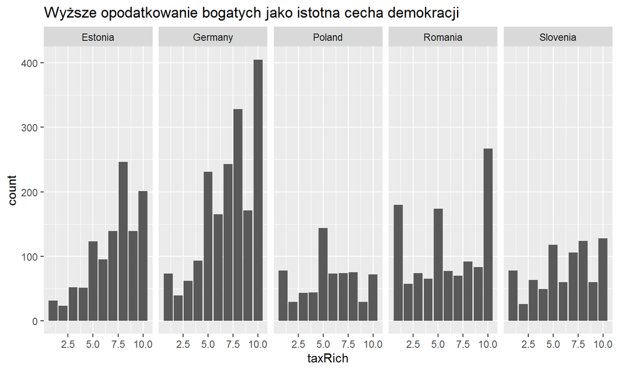

## Przegląd danych [3] - styl odpowiedzi

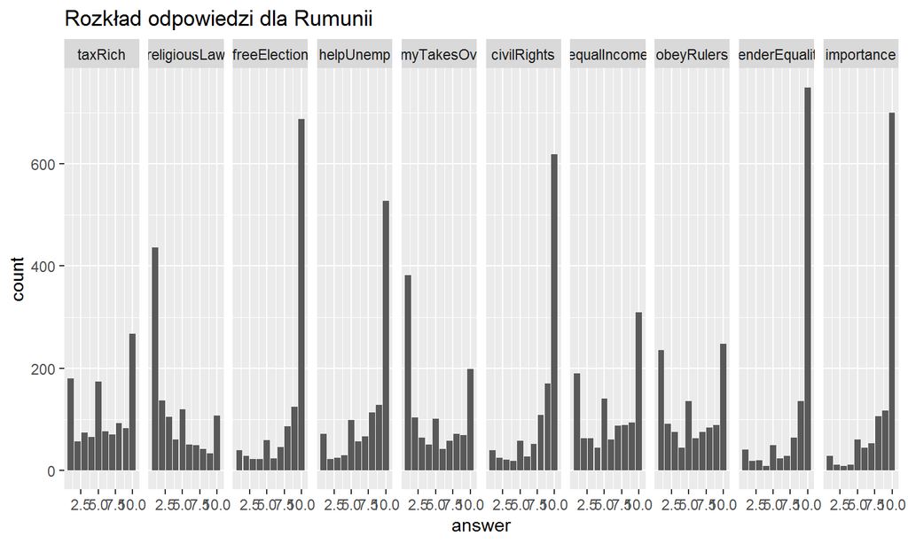

## Analiza korelacji [1]

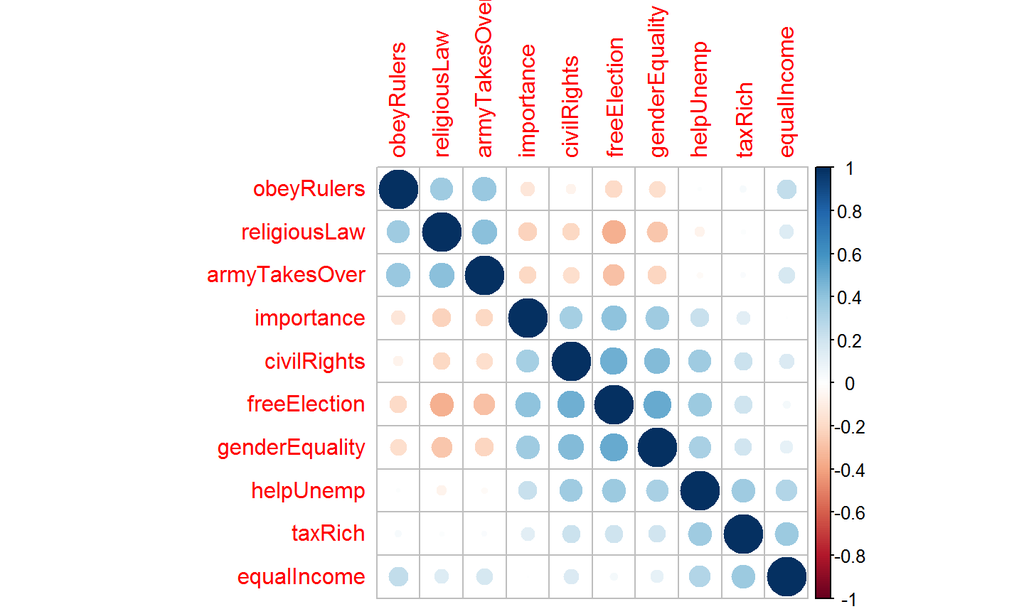

```r
library(corrplot)
cor.matrix <- cor(dem_data[,2:11], method="spearman")
corrplot(cor.matrix, method="circle", order='hclust')
```

## Analiza korelacji [2]

Są tu trzy główne skupiska:

- *fundamentalistyczne*: istotność autorytetów religijnych, posłuszeństwo wobec władzy i armia, która może przejąć władzę, gdy rząd jest niekompetentny
- *ekonomiczne*: państwo demokratyczne powinno opodatkować bogatych, a wspierać biednych, w demokracji powinny być w miarę równomierne zarobki
- *liberalne*: demokracja jest ważna, wiąże się z prawami człowieka, równością płci, wolnymi wyborami

Dodatkowo: państwo wspierające bezrobotnych pasuje zarówno do "libearlnej" jak i "ekonomiecznej" "liberalna" najbardziej "kłóci się" z "fundamentalistyczną"

## Model

```r
library(lavaan)

model <- '
fundamentalistic =~ obeyRulers + religiousLaw + armyTakesOver;
economic =~ taxRich + equalIncome + helpUnemp;
liberal =~ freeElection + genderEquality + civilRights + importance'

fit <- cfa(model, data = dem_data)
```

## Wyniki estymacji

```r
kable(parameterEstimates(fit)[,c(1:4, 7)], digits = 3, caption = "Wyniki estymacji")
```

Wyniki estymacji

| lhs | op | rhs | est | pvalue |
| --- | --- | --- | --- | --- |
| fundamentalistic | =~ | obeyRulers | 1.000 | NA |
| fundamentalistic | =~ | religiousLaw | 0.927 | 0 |
| fundamentalistic | =~ | armyTakesOver | 1.146 | 0 |
| economic | =~ | taxRich | 1.000 | NA |
| economic | =~ | equalIncome | 0.966 | 0 |
| economic | =~ | helpUnemp | 1.016 | 0 |
| liberal | =~ | freeElection | 1.000 | NA |
| liberal | =~ | genderEquality | 0.867 | 0 |
| liberal | =~ | civilRights | 0.921 | 0 |
| liberal | =~ | importance | 0.569 | 0 |
| obeyRulers | ~~ | obeyRulers | 6.555 | 0 |
| religiousLaw | ~~ | religiousLaw | 3.932 | 0 |
| armyTakesOver | ~~ | armyTakesOver | 4.979 | 0 |
| taxRich | ~~ | taxRich | 5.345 | 0 |
| equalIncome | ~~ | equalIncome | 6.369 | 0 |
| helpUnemp | ~~ | helpUnemp | 3.347 | 0 |
| freeElection | ~~ | freeElection | 2.006 | 0 |
| genderEquality | ~~ | genderEquality | 2.319 | 0 |
| civilRights | ~~ | civilRights | 3.310 | 0 |
| importance | ~~ | importance | 2.807 | 0 |
| fundamentalistic | ~~ | fundamentalistic | 2.623 | 0 |
| economic | ~~ | economic | 2.347 | 0 |
| liberal | ~~ | liberal | 2.225 | 0 |
| fundamentalistic | ~~ | economic | 0.609 | 0 |
| fundamentalistic | ~~ | liberal | -0.762 | 0 |
| economic | ~~ | liberal | 1.377 | 0 |

## Równoważność pomiarowa

## Poziomy równoważności

```r
configural <- cfa(model, data=dem_data, group="country")

weak <- cfa(model, data=dem_data, group="country", group.equal="loadings")

strong <- cfa(model, data=dem_data, group="country",
              group.equal=c("loadings", "intercepts"))

strict <- cfa(model, data=dem_data, group="country",
              group.equal=c("loadings", "intercepts", "residuals"))
```

```r
anova(configural, weak)
```

```
## Chi-Squared Difference Test
##
##             Df    AIC    BIC  Chisq Chisq diff Df diff Pr(>Chisq)
## configural 160 241495 242587 1106.9
## weak       188 241607 242514 1275.2     168.38      28  < 2.2e-16 ***
## ---
## Signif. codes:  0 '***' 0.001 '**' 0.01 '*' 0.05 '.' 0.1 ' ' 1
```

## Brak równoważności [1]

Porównanie grup

| lhs | op | rhs | Estonia | Germany | Poland | Romania | Slovenia |
| --- | --- | --- | --- | --- | --- | --- | --- |
| fundamentalistic | =~ | obeyRulers | 1.000 | 1.000 | 1.000 | 1.000 | 1.000 |
| fundamentalistic | =~ | religiousLaw | 1.068 | 0.911 | 0.972 | 1.019 | 3.961 |
| fundamentalistic | =~ | armyTakesOver | 1.142 | 0.982 | 1.412 | 1.263 | 3.363 |

## Brak równoważności [2]

[figure not shown]